# Optimización de pauta digital

Daniel Felipe Pérez Grajales* *Universidad Nacional de Colombia - Sede Medellín* *Efraín Galvis Amaya* *Universidad Nacional de Colombia - Sede Medellín* **Profesor**: *Juan David Ospina Arango* *Universidad Nacional de Colombia - Sede Medellín* *Departamento de Ciencias de la Computación y de la Decisión* *Decisiones bajo incertidumbre (Optimización para aprendizaje de máquina)

09 de junio de 2021

## Optimización de pauta digital

La plataforma digital de servicios QUIX quiere atraer más usuarios. Para ello invertirá en pauta digital. La pauta digital permite configurar las horas en la que las diferentes redes sociales le mostrarán los anuncios de la plataforma a los potenciales usuarios.

Se ha recogido información sobre datos de conexión de usuarios en un periodo de tiempo (ver adjunto). De acuerdo con esta información, ¿cómo debería distribuir su presupuesto de pauta digital la compañía?

### Datos de conexión de usuarios

|  | id_usuario | Calificadora | Correo | Fecha Consulta | Estado usuario |
| --- | --- | --- | --- | --- | --- |
| 1 | c2290d89dfc4 | Buró de Crédito | gmail.com | 19/01/21 9:20 | ACTIVO |
| 2 | 8d24ef1d52d8 | Buró de Crédito | gmail.com | 19/01/21 8:28 | ACTIVO |
| 3 | a5120d2c47fa | Buró de Crédito | gmail.com | 17/01/21 13:36 | ACTIVO |
| 4 | 5a5d70893606 | Buró de Crédito | edubc.mx | 20/01/21 9:27 | ACTIVO |
| 5 | 4a2082948031 | Buró de Crédito | gmail.com | 21/01/21 14:26 | ACTIVO |
| 6 | 41a54ce08fae | Buró de Crédito | oitlook.com | 18/01/21 16:13 | ACTIVO |

## Crear variables a partir de la fecha

|  | id_usuario | Calificadora | Correo | Fecha Consulta | Estado usuario | hora | Dia |
| --- | --- | --- | --- | --- | --- | --- | --- |
| 1 | c2290d89dfc4 | Buró de Crédito | gmail.com | 19/01/21 9:20 | ACTIVO | 9 | Martes |
| 2 | 8d24ef1d52d8 | Buró de Crédito | gmail.com | 19/01/21 8:28 | ACTIVO | 8 | Martes |
| 3 | a5120d2c47fa | Buró de Crédito | gmail.com | 17/01/21 13:36 | ACTIVO | 13 | Domingo |
| 4 | 5a5d70893606 | Buró de Crédito | edubc.mx | 20/01/21 9:27 | ACTIVO | 9 | Miércoles |
| 5 | 4a2082948031 | Buró de Crédito | gmail.com | 21/01/21 14:26 | ACTIVO | 14 | Jueves |
| 6 | 41a54ce08fae | Buró de Crédito | oitlook.com | 18/01/21 16:13 | ACTIVO | 16 | Lunes |

## Hora más frecuente

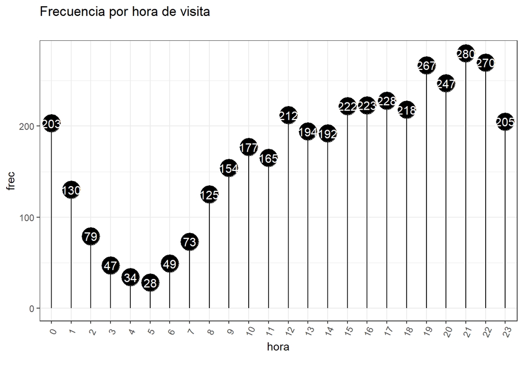

Las horas más frecuentes de conexión a nivel general se dan entre un rango de 7 pm a 10 pm siendo las más frecuente las 9 pm.

## frecuencia de hora de visita por estado de usuario

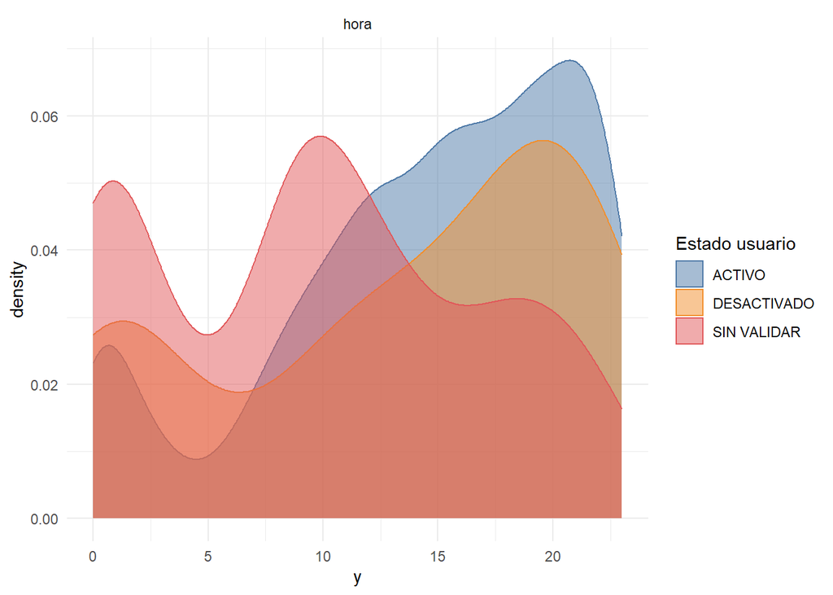

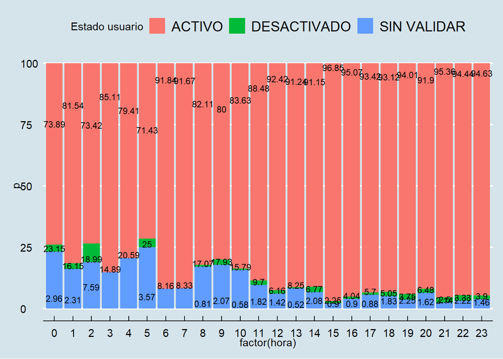

Se observa que tanto la función de densidad de los usuarios con estado Activo y Desactivado pueden venir de la misma distribición que genero los datos.Adicionalmente la conexión de usuarios activos se empieza a dar a partir de las 6 am.los usuarios de estado sin validar empiezan a tener conexión significativa en horas de la madrugada 12 am a 5 pm y 8 am a 10 am.

## Frecuencia por tipo de correo y estado de usuario

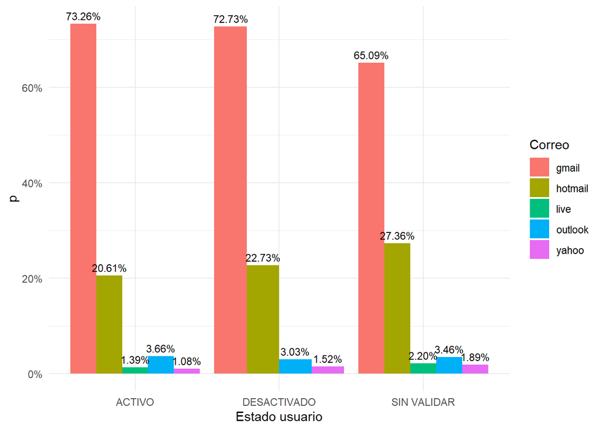

La identificación de correos de conexión es más frecuente en los diferentes estados el uso de correo Gmail, seguido de correos Hotmail.

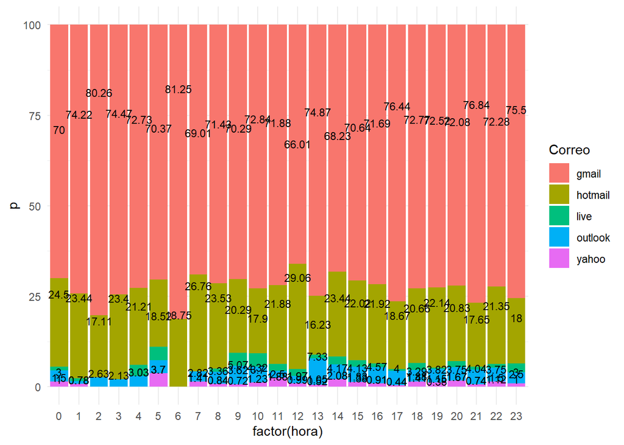

## Hora más visitada por Día

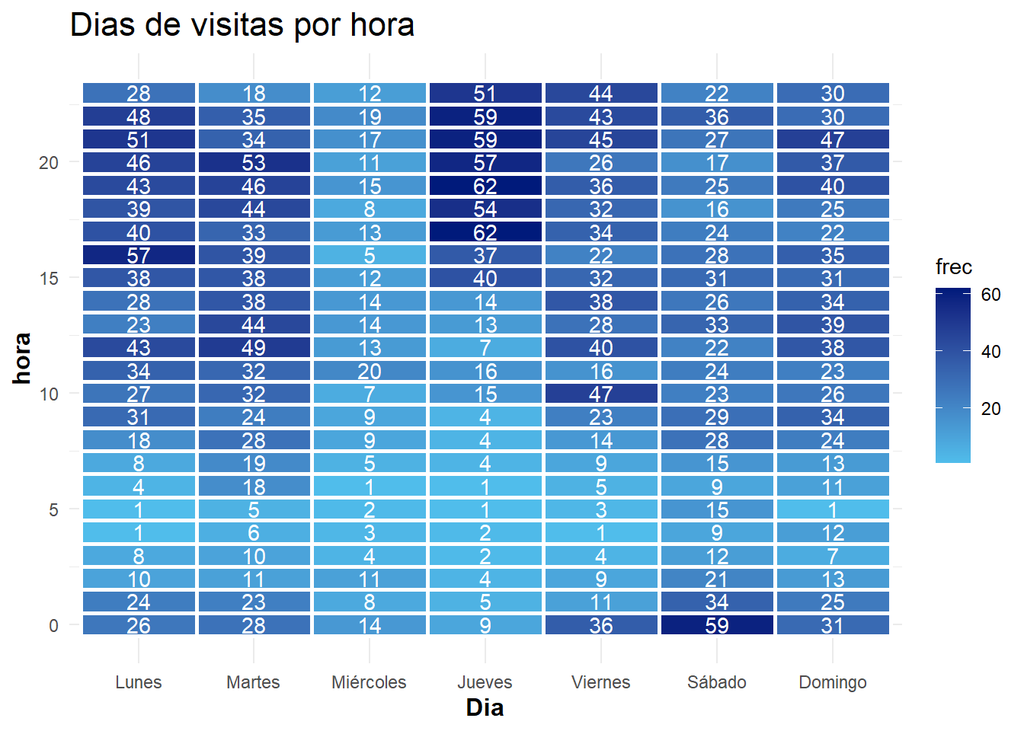

el Gráfico marca en azul las horas más frecuentes del día que se deben distribuir el presupuesto en pauta digital para las horas en la que las diferentes redes sociales le deberá mostrar los anuncios de la plataforma a los potenciales usuarios.como por ejemplo el día lunes pautar a las 12 pm y en un rango de 6 pm a 10 pm.El mejor día de pauta son los jueves de 5 pm a 11 pm.